# Transcriptomic and Pathway Analysis of TNBC and ER+ Breast Cancer

Ana Butkhuzi and Ericka Garcia

# 1 Transcriptomic and Pathway Analysis of TNBC and ER+ Breast Cancer

## 1.1 Biological Problem and Study Context

Breast cancer is a heterogeneous disease composed of multiple molecular subtypes with distinct molecular and clinical characteristics. Among these, triple-negative breast cancer (TNBC) is generally more aggressive and associated with poorer prognosis compared to estrogen receptor-positive (ER+) breast cancer. Understanding the transcriptional differences between these subtypes is important for improving diagnosis, prognosis, and therapeutic strategies.

The original study used paired-end RNA sequencing (RNA-seq) to investigate recurrent read-through fusion transcripts associated with breast cancer. Unlike classical fusion genes caused by genomic DNA rearrangements, these fusion transcripts are abnormal chimeric RNAs formed at the transcriptional and splicing level. Using RNA-seq and ChimeraScan analysis, the authors identified two recurrent fusion transcripts, SCNN1A-TNFRSF1A and CTSD-IFITM10, that were associated with breast cancer and detected in both TNBC and ER+ samples.

Although the original study focused on the discovery and validation of fusion transcripts, it did not investigate transcriptome-wide differential gene expression between TNBC and ER+ breast cancer samples. Therefore, the aim of the present analysis is to extend the original RNA-seq dataset by identifying global transcriptional differences between Triple Negative Breast Cancer and ER+ Primary Cancer samples. The subtype information used for this comparison is stored in the $sra.sample_attributes variable within the colData() object.

```r
# RNA-seq Analysis
library(DESeq2)
library(limma)
library(edgeR)
library(EDASeq)
library(genefilter)

# Data Handling
library(omicsdata)
library(dplyr)
library(plyr)

# Visualization
library(corrplot)
library(ggfortify)
library(ggplot2)
library(pheatmap)
library(ggrepel)
library(ggnewscale)
library(ggupset)
library(ggridges)

# Clustering
library(cluster)

# Enrichment & Pathways
library(clusterProfiler)
library(pathview)
library(ReactomePA)
library(enrichplot)

# Annotation
library(AnnotationDbi)
library(org.Hs.eg.db)

# Reporting
library(knitr)

# Table Aesthetics
library(kableExtra)
```

## 1.2 Exploratory analysis

A RangedSummarizedExperiment is a Bioconductor object used to store high-throughput genomic data, such as RNA-seq counts, together with associated information about genes and samples. It organizes the experiment into three main components: the assay data (e.g., expression counts), row metadata containing genomic ranges or gene annotations, and column metadata describing the biological samples.

The data for this analysis was stored in the breastcancer object and imported from the dataset file SRP042620.rds using the readRDS() function. This dataset originates from the study by Varley KE et al. titled “Recurrent read-through fusion transcripts in breast cancer” published in Breast Cancer Research and Treatment (2014).

```r
#load, visualize and confirm the class of the data
breastcancer <- readRDS("/opt/omicsdata/datasets/SRP042620.rds")
breastcancer
```

```
## class: RangedSummarizedExperiment
## dim: 63856 168
## metadata(8): time_created recount3_version ... annotation recount3_url
## assays(1): raw_counts
## rownames(63856): ENSG00000278704.1 ENSG00000277400.1 ...
##   ENSG00000182484.15_PAR_Y ENSG00000227159.8_PAR_Y
## rowData names(10): source type ... havana_gene tag
## colnames(168): SRR1313092 SRR1313062 ... SRR1313228 SRR1313229
## colData names(175): rail_id external_id ...
##   recount_pred.curated.cell_line BigWigURL
```

```r
class(breastcancer)
```

```
## [1] "RangedSummarizedExperiment"
## attr(,"package")
## [1] "SummarizedExperiment"
```

```r
#saving the SummarizedExperiment object with the original data
#save(breastcancer, file = "NGS_Ana Butkhuzi_Ericka Garcia.RData")
```

The dataset was first filtered to remove genes with zero counts across all samples, since genes with no detected expression do not contribute meaningful biological information and may introduce unnecessary noise into downstream analyses. This preprocessing step reduces dataset complexity and improves the reliability of normalization and differential expression analyses.

```r
# Identify genes with zero counts across all samples
table(rowSums(assay(breastcancer, "raw_counts")) == 0)
```

```
##
## FALSE  TRUE
## 57967  5889
```

```r
# Remove genes with total counts equal to zero
breastcancer <- breastcancer[rowSums(assay(breastcancer, "raw_counts")) > 0, ]
breastcancer
```

```
## class: RangedSummarizedExperiment
## dim: 57967 168
## metadata(8): time_created recount3_version ... annotation recount3_url
## assays(1): raw_counts
## rownames(57967): ENSG00000223972.5 ENSG00000278267.1 ...
##   ENSG00000237917.1 ENSG00000235857.1
## rowData names(10): source type ... havana_gene tag
## colnames(168): SRR1313092 SRR1313062 ... SRR1313228 SRR1313229
## colData names(175): rail_id external_id ...
##   recount_pred.curated.cell_line BigWigURL
```

The rowSums() function computes the total read counts for each gene across all samples. Genes with a total count equal to zero were identified and excluded from the dataset, while genes with counts greater than zero were retained. Initially, the dataset contained 63,856 genes and 168 samples. After filtering, the dataset contained 57,967 genes and 168 samples, indicating that 5,889 genes with zero counts were successfully removed.

As an initial step, the sample subtype annotations stored in the $sra.sample_attributes variable were examined using a frequency table to verify the composition of the dataset and confirm the presence of the groups of interest (i.e., ER+ and TNBC).

```r
table(breastcancer$sra.sample_attributes)
```

```
##
##                                                                 source_name;;Breast Cancer Cell Line|tissue;;Breast Cancer Cell Line
##                                                                                                                                   28
##                                                 source_name;;ER+ Breast Cancer Primary Tumor|tissue;;ER+ Breast Cancer Primary Tumor
##                                                                                                                                   42
##                                 source_name;;Reduction Mammoplasty - No known cancer|tissue;;Reduction Mammoplasty - No known cancer
##                                                                                                                                    5
##                         source_name;;Triple Negative Breast Cancer Primary Tumor|tissue;;Triple Negative Breast Cancer Primary Tumor
##                                                                                                                                   42
##   source_name;;Uninvolved Breast Tissue Adjacent to ER+ Primary Tumor|tissue;;Uninvolved Breast Tissue Adjacent to ER+ Primary Tumor
##                                                                                                                                   30
## source_name;;Uninvolved Breast Tissue Adjacent to TNBC Primary Tumor|tissue;;Uninvolved Breast Tissue Adjacent to TNBC Primary Tumor
##                                                                                                                                   21
```

The dataset contained multiple sample categories, including 42 ER+ breast cancer samples and 42 Triple Negative Breast Cancer (TNBC) samples, in addition to cancer cell lines, adjacent tissue samples, and samples with no known cancer classification. Since the objective of this analysis is to investigate transcriptomic differences between TNBC and ER+ breast cancer, only these two subtypes were retained for downstream analyses, while all other sample categories were excluded.

To focus the analysis on the two breast cancer subtypes of interest, a new metadata column called group was created inside the breastcancer object. Samples annotated as ER+ Primary Tumor were assigned to the “ER” group, while samples annotated as Triple Negative Breast Cancer Primary Tumor were assigned to the “TNBC” group. Samples belonging to other categories were temporarily labeled as NA.

```r
# Create a new group variable for the two subtypes of interest
breastcancer$group <- NA

# Assign ER+ primary tumor samples to the ER group
breastcancer$group[grepl("ER\\+ Breast Cancer Primary Tumor",
                         breastcancer$sra.sample_attributes)] <- "ER"

# Assign TNBC primary tumor samples to the TNBC group
breastcancer$group[grepl("Triple Negative Breast Cancer Primary Tumor",
                         breastcancer$sra.sample_attributes)] <- "TNBC"

# Check the number of samples in each group
table(breastcancer$group)
```

```
##
##   ER TNBC
##   42   42
```

```r
# Visualize the group assignment
breastcancer$group
```

```
##   [1] "ER"   NA     NA     NA     NA     NA     NA     NA     NA     NA
##  [11] NA     NA     NA     NA     NA     NA     NA     NA     NA     NA
##  [21] NA     NA     NA     NA     "ER"   "ER"   "ER"   "ER"   "ER"   "ER"
##  [31] "ER"   "ER"   "ER"   "ER"   "ER"   "ER"   "ER"   "ER"   "ER"   "ER"
##  [41] "ER"   "ER"   "ER"   "ER"   "ER"   "ER"   "ER"   "ER"   "ER"   "ER"
##  [51] "ER"   "ER"   "ER"   "ER"   "ER"   "ER"   "ER"   "ER"   "ER"   "ER"
##  [61] "ER"   "TNBC" "TNBC" "TNBC" "TNBC" "TNBC" "TNBC" "TNBC" "TNBC" "TNBC"
##  [71] "TNBC" "TNBC" "TNBC" "TNBC" "TNBC" "TNBC" "TNBC" "TNBC" "TNBC" "TNBC"
##  [81] "TNBC" "TNBC" "TNBC" "TNBC" "TNBC" "TNBC" "TNBC" "TNBC" "TNBC" "TNBC"
##  [91] "TNBC" "TNBC" "TNBC" "TNBC" NA     NA     NA     NA     NA     NA
## [101] NA     NA     NA     NA     NA     NA     NA     NA     NA     NA
## [111] NA     NA     NA     NA     NA     NA     NA     NA     NA     NA
## [121] NA     NA     "ER"   "ER"   "ER"   "ER"   "TNBC" "TNBC" "TNBC" "TNBC"
## [131] "TNBC" "TNBC" "TNBC" "TNBC" "TNBC" NA     NA     NA     NA     NA
## [141] NA     NA     NA     NA     NA     NA     NA     NA     NA     NA
## [151] NA     NA     NA     NA     NA     NA     NA     NA     NA     NA
## [161] NA     NA     NA     NA     NA     NA     NA     NA
```

The grepl() function was used to search the sample annotation column and identify samples matching the two cancer subtypes. This step confirmed that the dataset contained 42 ER+ samples and 42 TNBC samples, resulting in a balanced comparison between the two groups.

```r
# Keep only samples assigned to either ER or TNBC
breastcancer <- breastcancer[, !is.na(breastcancer$group)]

# Confirm that no unassigned samples remain
sum(is.na(breastcancer$group))
```

```
## [1] 0
```

```r
summary(breastcancer$group)
```

```
##    Length  N.unique   N.blank Min.nchar Max.nchar
##        84         2         0         2         4
```

After assigning the groups, the breastcancer object was subsetted to retain only samples classified as ER or TNBC. Samples with NA values in the group column were removed because they corresponded to categories outside the scope of this analysis, such as cancer cell lines, adjacent tissues, or samples with no known cancer classification. After filtering, the dataset contained 84 samples in total, with no remaining unassigned samples.

The filtered RNA-seq count matrix was inspected to verify the structure of the data and evaluate the distribution of expression counts across samples. In addition, the sample metadata was checked to confirm that all retained samples were correctly assigned to the ER or TNBC groups.

```r
# Visualize the first six genes and first six samples
assay(breastcancer, "raw_counts")[1:6, 1:6]
```

```
##                   SRR1313092 SRR1313090 SRR1313091 SRR1313093 SRR1313094
## ENSG00000223972.5       2107        111        974       1200       3345
## ENSG00000278267.1      13683       3047       8945      14582      12214
## ENSG00000227232.5     240885     106219     202379     241276     273006
## ENSG00000284332.1          0          0          0         48          0
## ENSG00000243485.5        131         50        100        455        168
## ENSG00000237613.2        340         10          0       1032        128
##                   SRR1313095
## ENSG00000223972.5        884
## ENSG00000278267.1      12203
## ENSG00000227232.5     233549
## ENSG00000284332.1         72
## ENSG00000243485.5        903
## ENSG00000237613.2        157
```

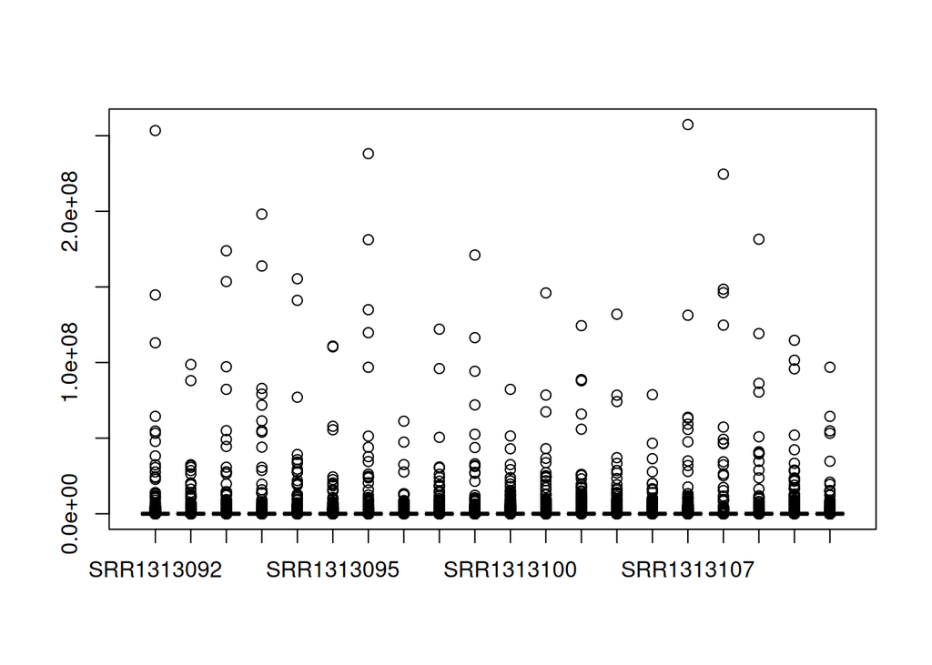

```r
# Visualize the distribution of raw counts for the first 20 samples
boxplot(assay(breastcancer, "raw_counts")[, 1:20])
```

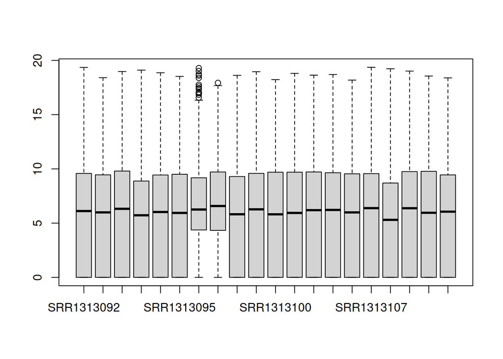

```r
# Apply log1p transformation and visualize the distribution again
boxplot(log1p(assay(breastcancer, "raw_counts"))[, 1:20])
```

```r
# Confirm that the group column was correctly created
colData(breastcancer)[, "group", drop = FALSE]
```

```
## DataFrame with 84 rows and 1 column
##                  group
##            <character>
## SRR1313092          ER
## SRR1313090          ER
## SRR1313091          ER
## SRR1313093          ER
## SRR1313094          ER
## ...                ...
## SRR1313155        TNBC
## SRR1313156        TNBC
## SRR1313157        TNBC
## SRR1313166        TNBC
## SRR1313167        TNBC
```

A new object named raw_counts_plot was created from the filtered count matrix and was consistently used throughout the analysis for downstream visualizations, including ggplot2 graphics, PCA analyses, and other exploratory plots. Boxplots were then used to examine the distribution of expression values across samples before and after applying a log1p() transformation (log(1 + count)), which reduces the effect of highly expressed genes and improves visualization of RNA-seq count distributions. Finally, the group column from the colData() object was displayed to verify the correct classification of samples into the ER and TNBC subtypes.

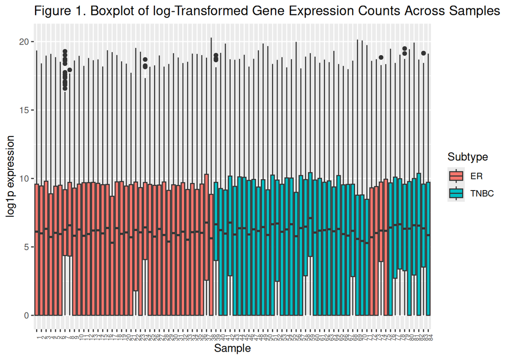

```r
# Figure 1. Boxplot of log-Transformed Gene Expression Counts Across Samples

library(tidyverse)
# Extract raw counts from the breastcancer object
raw_counts_plot <- assay(breastcancer, "raw_counts")

# Rename samples as 1, 2, 3, ... up to the total number of samples
colnames(raw_counts_plot) <- as.character(seq_len(ncol(raw_counts_plot)))

# Apply log1p transformation and convert to data frame
df <- as.data.frame(log1p(raw_counts_plot))

# Keep gene identifiers
df$gene <- rownames(df)

# Convert to long format for ggplot
df_long <- df %>%
  pivot_longer(
    cols = -gene,
    names_to = "sample",
    values_to = "expression"
  )

# Add subtype information
df_long$subtype <- breastcancer$group[as.numeric(df_long$sample)]

# Generate boxplot for all samples
ggplot(df_long,
       aes(x = factor(sample,
                      levels = as.character(seq_len(ncol(raw_counts_plot)))),
           y = expression,
           fill = subtype)) +
  geom_boxplot() +
  labs(title = "Figure 1. Boxplot of log-Transformed Gene Expression Counts Across Samples",
       x = "Sample",
       y = "log1p expression",
       fill = "Subtype") +
  theme(axis.text.x = element_text(angle = 90, size = 6))
```

The boxplot confirms that the dataset contains samples from the two breast cancer subtypes of interest, ER and TNBC, as indicated by the subtype color coding. The distributions still reflect unnormalized RNA-seq count data, which is expected at this stage of the workflow since no normalization procedures have yet been applied. The observed variability between samples further justifies the need for downstream normalization prior to differential gene expression analysis.

## 1.3 MD and MA charts

To further assess the distribution and variability of the RNA-seq count data, MA and MD plots were generated as exploratory quality control analyses. These plots help visualize expression differences, detect systematic technical bias, and evaluate the consistency of gene expression measurements across samples prior to normalization.

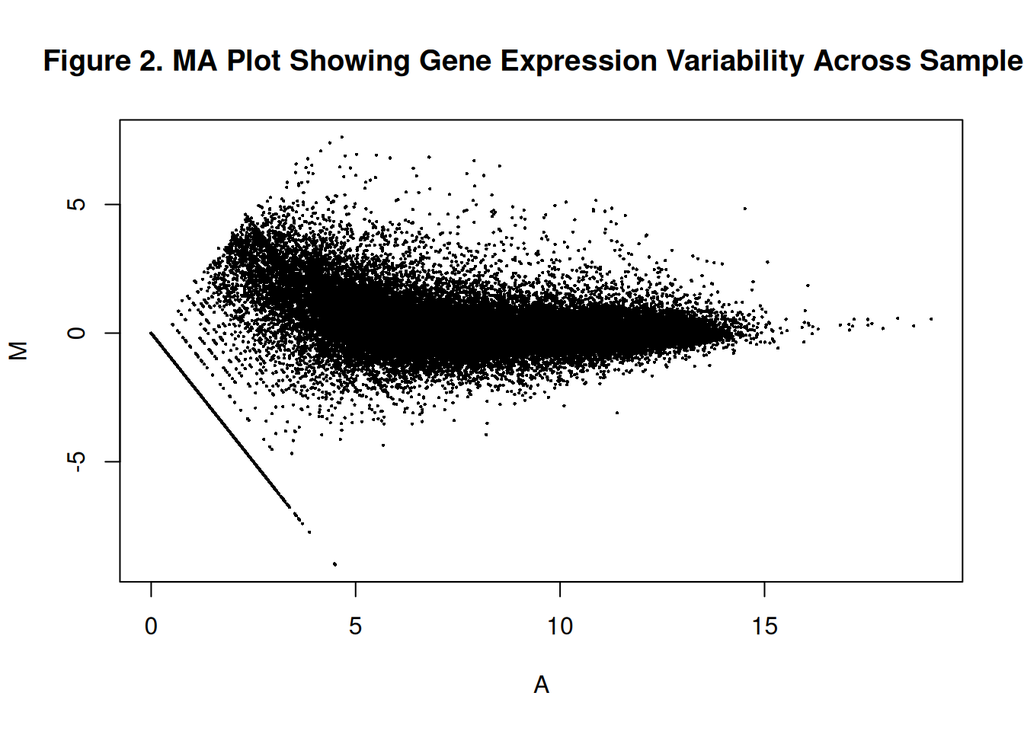

```r
# MA plot
limma::plotMA(
  log1p(assay(breastcancer, "raw_counts")),
  main = "Figure 2. MA Plot Showing Gene Expression Variability Across Samples",
  xlab = "A",
  ylab = "M"
)
```

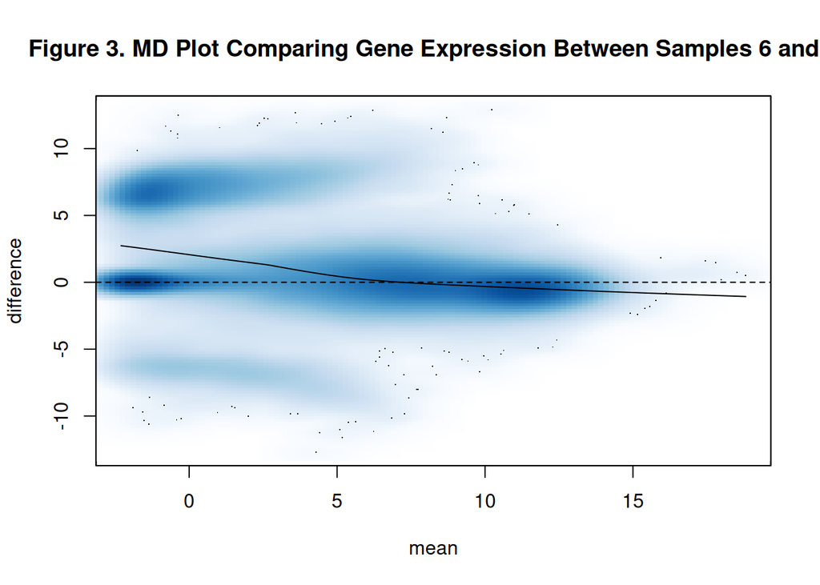

```r
# MD plot comparing samples 6 and 7
MDPlot(
  assay(breastcancer, "raw_counts"),
  c(6, 7),
  main = "Figure 3. MD Plot Comparing Gene Expression Between Samples 6 and 7"
)
```

The MA plot compares each gene to its average expression across all samples. The x-axis (A) represents the overall average expression level of each gene, while the y-axis (M) represents how much the expression of that gene deviates from its average level. Ideally, the points should be centered around the horizontal line at M = 0, indicating the absence of strong systematic bias. In this dataset, genes with low expression levels show greater variability, while highly expressed genes appear more stable, which is commonly observed in raw RNA-seq count data.

The MD plot directly compares gene expression between samples 6 and 7, which belong to the same breast cancer subtype. Most genes are centered around zero, indicating that the two samples are generally similar in their expression profiles. However, the presence of a non-flat trend and increased variability among lowly expressed genes suggests technical bias and sample-to-sample variability. These observations indicate that normalization is required before performing downstream differential gene expression analyses.

## 1.4 RLE plot

Relative Log Expression (RLE) plots were generated as an additional quality control step to evaluate variability between samples before normalization. RLE plots assess how much the expression of each gene in a sample deviates from the median expression of that gene across all samples. Ideally, the boxplots should be centered around zero with similar spreads across samples. Systematic deviations from zero or large differences in spread may indicate technical variation, library size differences, or other biases that require normalization.

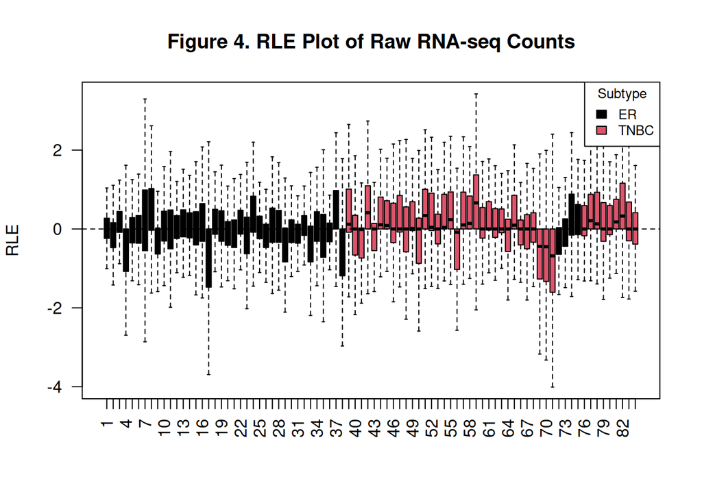

```r
# Create colors based on breast cancer subtype
col <- as.factor(breastcancer$group)
levels(col) <- c(1, 2)

# Create numerical labels for samples
sample_labels <- seq_len(ncol(assay(breastcancer, "raw_counts")))

# Generate RLE plot
plotRLE(
  assay(breastcancer, "raw_counts"),
  outline = FALSE,
  las = 2,
  names = sample_labels,
  ylab = "RLE",
  main = "Figure 4. RLE Plot of Raw RNA-seq Counts",
  col = col
)

# Add legend
legend(
  "topright",
  legend = c("ER", "TNBC"),
  fill = c(1, 2),
  title = "Subtype",
  cex = 0.8
)
```

## 1.5 PCA

Principal Component Analysis (PCA) was performed as an exploratory analysis to evaluate the overall variability and clustering patterns among ER and TNBC samples based on their gene expression profiles. PCA reduces the dimensionality of the RNA-seq dataset by summarizing the major sources of variation into principal components, allowing visualization of similarities and differences between samples.

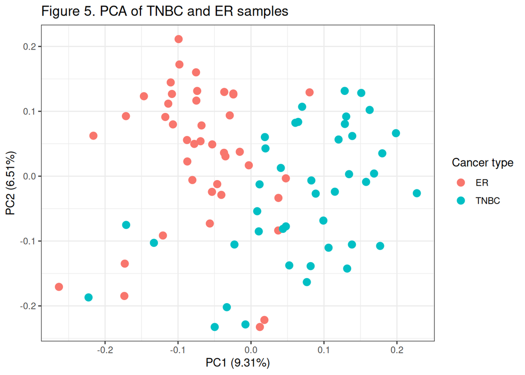

```r
# log transform
pca <- prcomp(t(log1p(raw_counts_plot)))

# make sure group is a factor
colData(breastcancer)$group <- factor(colData(breastcancer)$group, levels = c("ER", "TNBC"))

# PCA plot colored by cancer type
autoplot(
  pca,
  data = as.data.frame(colData(breastcancer)),
  colour = "group",
  size = 3
) +
  labs(title = "Figure 5. PCA of TNBC and ER samples", colour = "Cancer type") +
  theme_bw()
```

The PCA plot shows a partial separation between ER and TNBC samples, indicating that the two breast cancer subtypes exhibit distinct gene expression patterns. However, some overlap between groups is still observed, suggesting biological heterogeneity within each subtype and shared transcriptional characteristics between ER and TNBC samples.

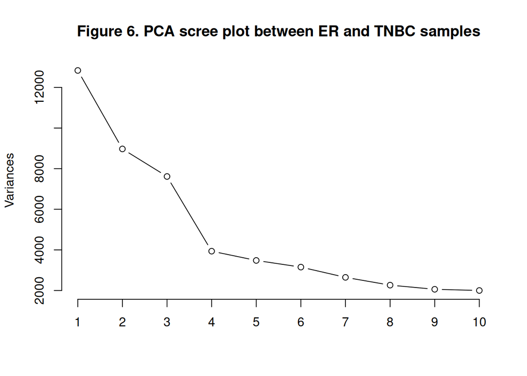

```r
screeplot(pca, type = c("lines"), main = "Figure 6. PCA scree plot between ER and TNBC samples")
```

According to the PCA scree plot, the first four principal components explain the largest proportion of variability in the dataset, as indicated by the steep decline in variance observed from PC1 to PC4. After the fourth component, the decrease in variance becomes more gradual, suggesting that additional principal components contribute less substantially to the overall variability in gene expression data.

## 1.6 GC content

GC content bias evaluation was performed to assess whether gene expression measurements were influenced by the proportion of guanine (G) and cytosine (C) nucleotides present within each gene. Ideally, RNA-seq expression values should reflect true biological differences; however, sequencing and amplification technologies can preferentially capture genes with certain GC compositions, introducing technical bias into the dataset.

Gene identifiers were extracted from the breastcancer dataset, which represents the RNA-seq dataset analyzed throughout this study, and matched to annotation information from the human reference genome `hg38`. The `getGeneLengthAndGCContent()` function was then used to retrieve gene length and GC-content values for each gene present in the dataset.

```r
# Extract gene IDs from breastcancer dataset and create a vector with 57967 labels, one per gene
ensid <- as.character(rowRanges(breastcancer)$gene_id)

# Keep only the core Ensembl gene ID
ensid <- substr(ensid, 1, 15)

# Retrieve gene length and GC content information
gc <- getGeneLengthAndGCContent(
  id = ensid,
  org = "hg38",
  mode = "org.db"
)
```

During annotation retrieval, a warning indicating a “1:many mapping” between gene identifiers and annotation entries was observed. This occurs because some Ensembl gene IDs correspond to multiple annotation records or transcript variants within the reference database and is a common occurrence in genomic annotation workflows.

The resulting object, gc, is a numeric matrix containing gene ID (excluding version number), gene length and GC-content information for each gene.

### 1.6.1 GC content inspection

Subsequently, the gc matrix was inspected to determine the number of missing values (NA) present in the GC content and gene length annotations.

```r
table(is.na(gc[,2])) #counts of genes with NA inside `gc` object
```

```
##
## FALSE  TRUE
## 26857 31110
```

During inspection of the matrix, 31110 genes were found to contain missing values (NA). These genes were removed because incomplete annotation information prevents accurate evaluation of GC-related technical bias.

```r
gc <- gc[!is.na(gc[,2]),] # this function keeps only genes, where gc is not missing.

table(is.na(gc[,2]))
```

```
##
## FALSE
## 26857
```

After removing genes with missing GC-content information, a cleaned gc object was obtained containing the processed gene identifiers from the breastcancer dataset.

The next steps further processed the breastcancer, ensid, and gc objects to ensure proper matching between gene expression counts and GC-content annotations. First, the preprocessed ensid vector, created from the breastcancer dataset, was added to the breastcancer object as a new column within the rowData() metadata, since these gene identifiers no longer contained version numbers after the decimal point. At this stage, the dimensions of the breastcancer dataset were 57,967 genes and 84 samples.

```r
rowData(breastcancer)$ensid = ensid # ensid vector added to rowData matrix
dim(breastcancer)
```

```
## [1] 57967    84
```

Next, the gc object was used to match GC-content information with the processed ensid values previously incorporated into the breastcancer object. This step filtered the 57967 genes by retaining 26857 genes which were found both in the annotation database and within the ensid vector from the breastcancer dataset, ensuring that gene expression values and GC-content annotations corresponded to the same set of genes.

```r
# Keep only genes in the breastcancer dataset that are also found in the gc annotation matrix
breastcancer <- breastcancer[rowData(breastcancer)$ensid %in% rownames(gc),]
dim(breastcancer)
```

```
## [1] 26857    84
```

After filtering the genes to retain only those shared between the breastcancer dataset and the GC-content annotation matrix (gc object), the next steps ensured that the gc annotation matrix and the RNA-seq count matrix corresponded to the exact same genes in the same order.

First, the gc matrix was reordered according to the processed ensid gene identifiers stored within the breastcancer dataset, ensuring that the GC-content annotations followed the same gene order as the expression data.

```r
# Reorder the gc matrix to follow the cleaned ensid gene order stored in the breastcancer dataset
gc <- gc[rowData(breastcancer)$ensid, ]

# Extract the raw RNA-seq count matrix from the breastcancer dataset
raw_counts <- assay(breastcancer, "raw_counts")

# Replace row names of the count matrix in breastcancer with the processed and cleaned ensid gene identifiers
rownames(raw_counts) <- rowData(breastcancer)$ensid
```

A new object of class **SeqExpressionSet** was created to visualize the GC content using the function `newSeqExpressionSet()` from the *EDASeq* package.

```r
set <- newSeqExpressionSet(raw_counts,
                           phenoData = AnnotatedDataFrame(data.frame(conditions = factor(1:ncol(raw_counts)),
                                                                     row.names = colnames(raw_counts))),
                           featureData = AnnotatedDataFrame(data.frame(gc = gc[, 2], l = gc[, 1])))
```

To visualize the GC content for each sample we use the `biasPlot()` function.

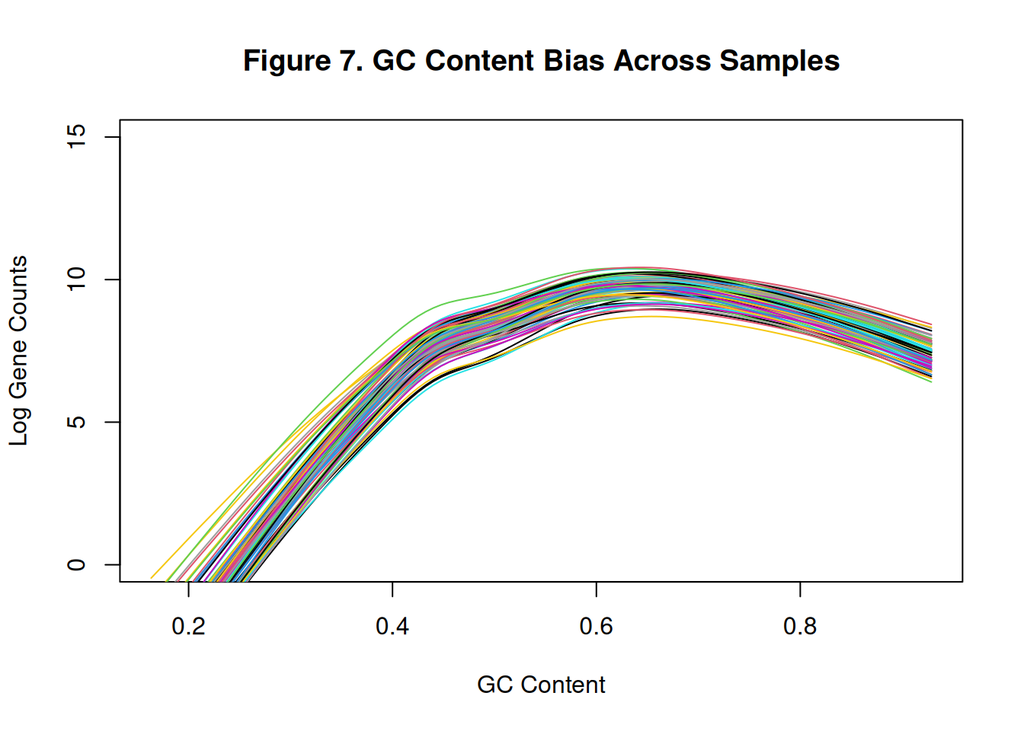

```r
EDASeq::biasPlot(
  set,
  "gc",
  ylim = c(0, 15),
  log = TRUE,
  xlab = "GC Content",
  ylab = "Log Gene Counts",
  main = "Figure 7. GC Content Bias Across Samples",
  legend = FALSE,
  col = 1:ncol(counts(set))
)

legend(
  "right",
  inset = c(-0.18, 0),
  legend = seq_len(ncol(counts(set))),
  col = 1:ncol(counts(set)),
  lty = 1,
  cex = 0.7,
  title = "Sample ID",
  xpd = TRUE
)
```

The GC-content bias plot shows the relationship between GC content and gene expression levels across all samples. Overall, the curves display a similar pattern, indicating good consistency between samples and suggesting that the observed bias is systematic rather than sample-specific.

Gene counts increase as GC content increases up to approximately 60% GC, after which expression levels begin to decrease. This pattern suggests the presence of GC-related technical bias, which is commonly observed in RNA-seq data and may result from sequencing, amplification, or alignment preferences for genes with intermediate GC content.

Next, the trend of the log-ratio of gene expression between samples 1 and 3 was examined as GC content changes, allowing visualization of how GC composition may influence differences in expression measurements between the two samples, from the same group (i.e., ER).

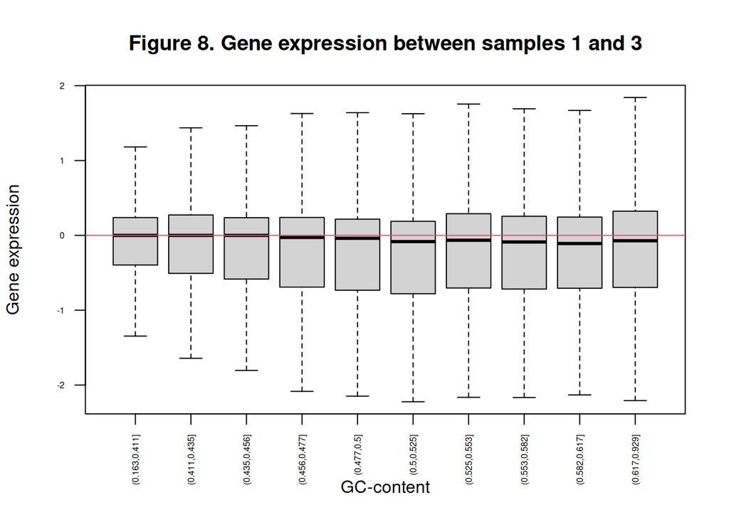

```r
lrt <- log(raw_counts[, 1] + 1) - log(raw_counts[, 3] + 1)
biasBoxplot(lrt, gc[, 2], outline = FALSE, xlab = "GC-content", ylab = "Gene expression", las = 2, cex.axis = 0.5, main = "Figure 8. Gene expression between samples 1 and 3")
```

Next, the trend of the log-ratio of gene expression between sample 1 (ER subtype) and sample 84 (TNBC subtype) was examined as GC content changes.

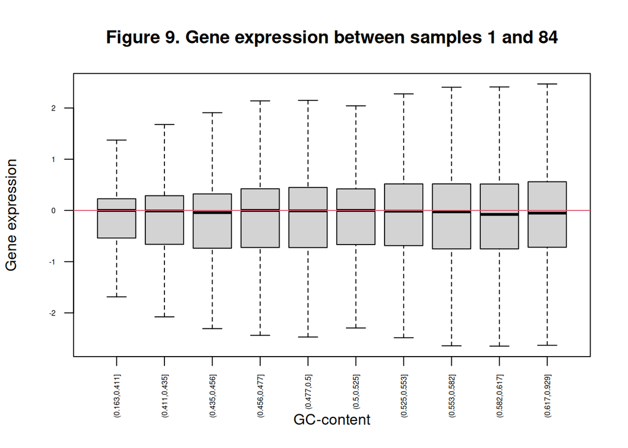

```r
lrt <- log(raw_counts[, 1] + 1)- log(raw_counts[, 84] + 1)
biasBoxplot(lrt, gc[, 2], outline = FALSE, xlab = "GC-content", ylab = "Gene expression", las = 2, cex.axis = 0.5, main = "Figure 9. Gene expression between samples 1 and 84")
```

## 1.7 Filtering

To initiate normalization, genes with all zero counts had already been removed in previous steps. However, genes with extremely low counts can still introduce noise and reduce the reliability of downstream analyses. Therefore, only genes with total raw counts greater than or equal to 10 were retained in a newly created object named breastcancer_sel, which was generated from the original breastcancer dataset. Thus, both objects contain the same samples and structure, except that breastcancer_sel excludes genes with fewer than 10 total counts.

```r
breastcancer_sel <- breastcancer[rowSums(assay(breastcancer, "raw_counts")) >= 10, ]
dim(breastcancer_sel)
```

```
## [1] 26772    84
```

```r
class(breastcancer_sel)
```

```
## [1] "RangedSummarizedExperiment"
## attr(,"package")
## [1] "SummarizedExperiment"
```

In addition, a new object named set_sel was created from the previously generated set object, which is a SeqExpressionSet created for GC-content visualization and normalization analyses. Similar to breastcancer_sel, the set_sel object retained only genes with total raw counts greater than or equal to 10, ensuring consistency between both filtered datasets.

```r
set_sel <- set[rownames(set) %in% rowData(breastcancer_sel)$ensid, ]
dim(set_sel)
```

```
## Features  Samples
##    26772       84
```

After filtering, 85 low-count genes were removed, reducing the dataset from 26,857 to 26,772 genes in both filtered objects (i.e., breastcancer_sel and set_sel).

# 2 Normalization

Normalization of RNA-seq read counts is an essential procedure that corrects for non-biological variation of samples due to library preparation, sequencing read depth, gene length, mapping bias and other technical issues. Normalization is composed of two main steps: within-sample normalization and between-sample normalization.

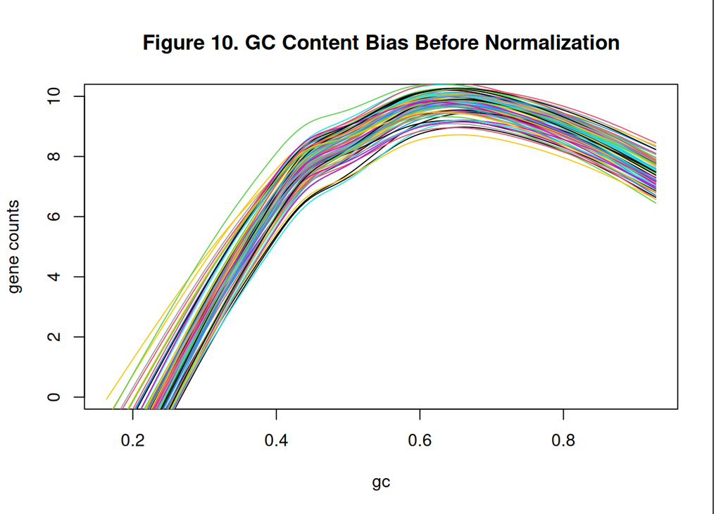

```r
before <- biasPlot(
  set_sel,
  "gc",
  ylim = c(0, 10),
  log = TRUE,
  main = "Figure 10. GC Content Bias Before Normalization",
  legend = FALSE
)

legend(
  "right",
  inset = c(-0.15, 0),
  legend = seq_len(ncol(counts(set_sel))),
  col = 1:ncol(counts(set_sel)),
  lty = 1,
  cex = 0.6,
  title = "Sample ID",
  xpd = TRUE
)
```

In this plot, each curve represents one sample. The x-axis groups genes according to GC content, while the y-axis shows the average gene counts for genes within each GC-content range. Ideally, the curves should appear relatively flat, indicating minimal dependence of expression values on GC composition.

The results obtained after filtering low-count genes were very similar to those observed in Figure 7. GC Content Bias Across Samples, which is expected since only 85 genes were removed during filtering. However, some samples still display different trends compared to others, indicating the presence of GC-related technical bias. Therefore, within-sample normalization was required to reduce this effect.

## 2.1 Within sample normalization

To perform within-sample normalization, the withinLaneNormalization() function from the EDASeq package was applied Within-sample using three different methods under the withinLaneNormalization() function: upper, median, and full.

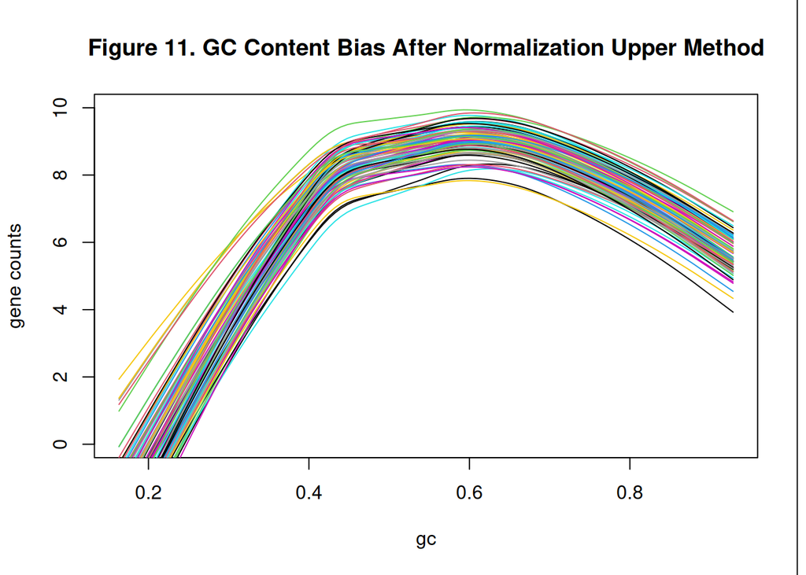

```r
wt <- withinLaneNormalization(set_sel, "gc" , which = "upper", offset = TRUE)

after <- biasPlot(wt, "gc", ylim = c(0, 10), log = TRUE, main = "Figure 11. GC Content Bias After Normalization Upper Method", legend = FALSE)

legend(
  "right",
  inset = c(-0.15, 0),
  legend = seq_len(ncol(counts(set_sel))),
  col = 1:ncol(counts(set_sel)),
  lty = 1,
  cex = 0.6,
  title = "Sample ID",
  xpd = TRUE
)
```

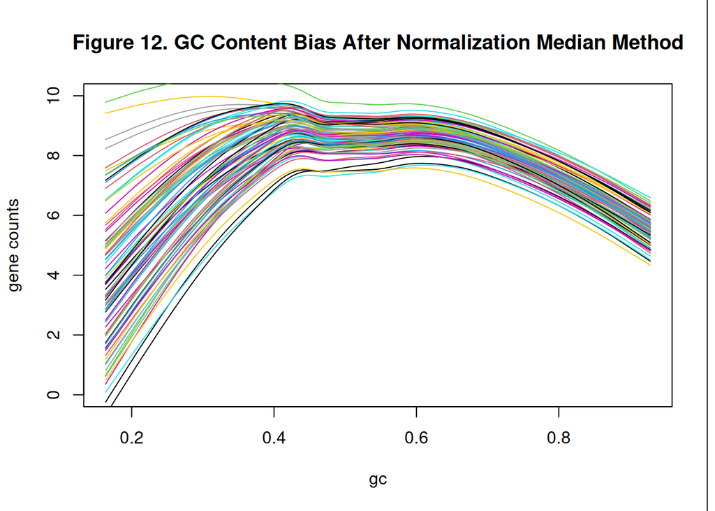

```r
wt <- withinLaneNormalization(set_sel, "gc" , which = "median", offset = TRUE)

after_median <- biasPlot(wt, "gc", ylim = c(0, 10), log = TRUE, legend = FALSE, main = "Figure 12. GC Content Bias After Normalization Median Method")

legend(
  "right",
  inset = c(-0.15, 0),
  legend = seq_len(ncol(counts(set_sel))),
  col = 1:ncol(counts(set_sel)),
  lty = 1,
  cex = 0.6,
  title = "Sample ID",
  xpd = TRUE
)
```

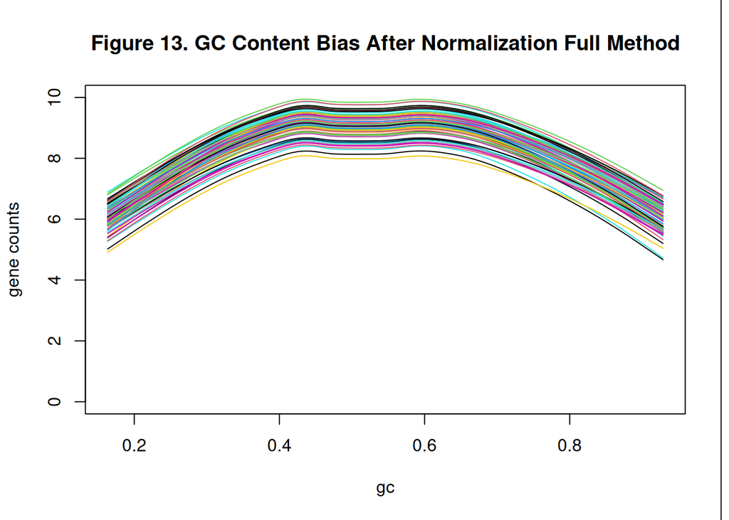

```r
wt <- withinLaneNormalization(set_sel, "gc" , which = "full", offset = TRUE)

after_full <- biasPlot(wt, "gc", ylim = c(0, 10), log = TRUE, legend = FALSE,main = "Figure 13. GC Content Bias After Normalization Full Method" )

legend(
  "right",
  inset = c(-0.15, 0),
  legend = seq_len(ncol(counts(set_sel))),
  col = 1:ncol(counts(set_sel)),
  lty = 1,
  cex = 0.6,
  title = "Sample ID",
  xpd = TRUE
)
```

Upper: This method preserved the overall structure of the data while introducing only mild corrections to the GC-content bias. Although the improvement was moderate, the sample distributions remained stable and biologically consistent, making this method a more conservative normalization approach. Median: This method introduced noticeable distortions into the data. The normalized plots showed more irregular trends between samples compared to the original data, suggesting that the correction negatively affected the expression distributions. Full: This method substantially reduced the GC-content bias and produced more clustered sample curves. However, the correction appeared relatively strong and may have over-adjusted the data, potentially removing part of the biological variability together with the technical bias.

Considering the balance between bias correction and preservation of the original expression structure, the upper method was selected for downstream analyses because it provided a more moderate and less aggressive normalization approach.

## 2.2 Between samples normalization

After within-sample normalization, between-sample normalization was performed to reduce global technical differences between samples, such as sequencing depth and library size. The `betweenLaneNormalization()` function from the *EDASeq* package was used to evaluate both the full and upper normalization methods.

```r
#EDASeq normalization package:
# offset = TRUE: normalized value returns as an offset leaving the original counts unchanged
set_full <- betweenLaneNormalization(set_sel, which = "full", offset = TRUE)

set_uq <- betweenLaneNormalization(set_sel, which = "upper", offset = TRUE)
```

The normalized count matrices generated from both normalization methods were then extracted and stored for downstream analyses under the objects: `full`(Full Method) and `uq_edaseq`(Upper Method).

```r
# save the normalized matrix into an object
full <- set_full@assayData$normalizedCounts

uq_edaseq <- set_uq@assayData$normalizedCounts
```

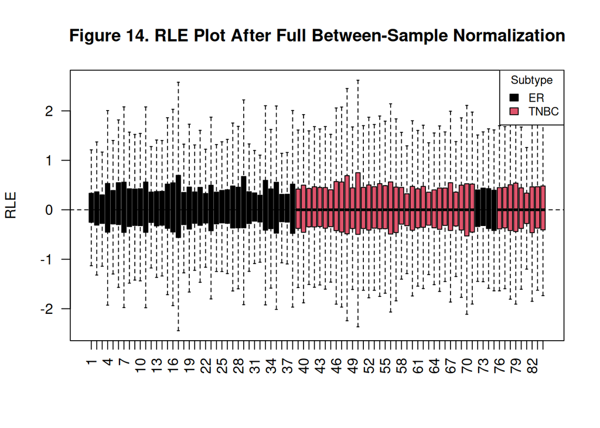

```r
# Figure 14. RLE Plot After Between-Sample Normalization Using the Full Method

plotRLE(
  full,
  outline = FALSE,
  las = 2,
  names = seq_len(ncol(full)),
  ylab = "RLE",
  main = "Figure 14. RLE Plot After Full Between-Sample Normalization",
  col = col
)

legend(
  "topright",
  legend = c("ER", "TNBC"),
  fill = c(1, 2),
  title = "Subtype",
  cex = 0.8
)
```

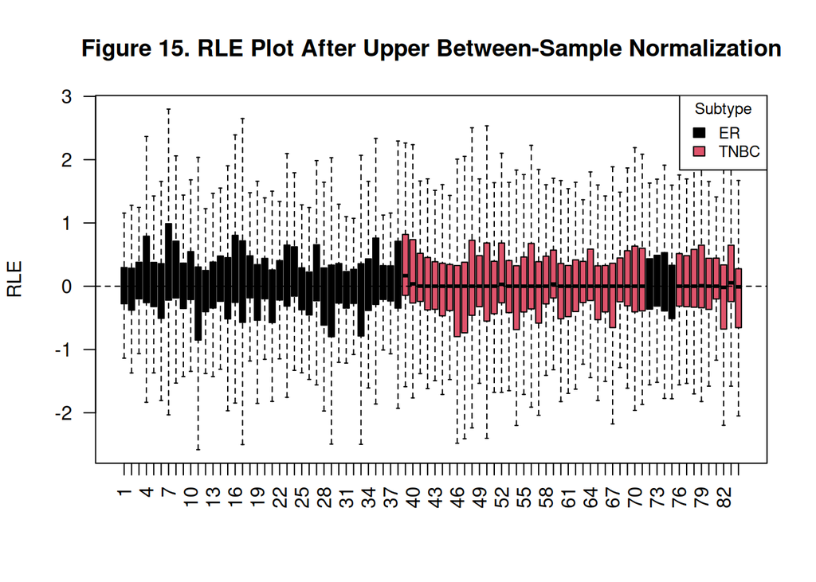

```r
# Figure 15. RLE Plot After Between-Sample Normalization Using the Upper Method

plotRLE(
  uq_edaseq,
  outline = FALSE,
  las = 2,
  names = seq_len(ncol(uq_edaseq)),
  ylab = "RLE",
  main = "Figure 15. RLE Plot After Upper Between-Sample Normalization",
  col = col
)

legend(
  "topright",
  legend = c("ER", "TNBC"),
  fill = c(1, 2),
  title = "Subtype",
  cex = 0.8
)
```

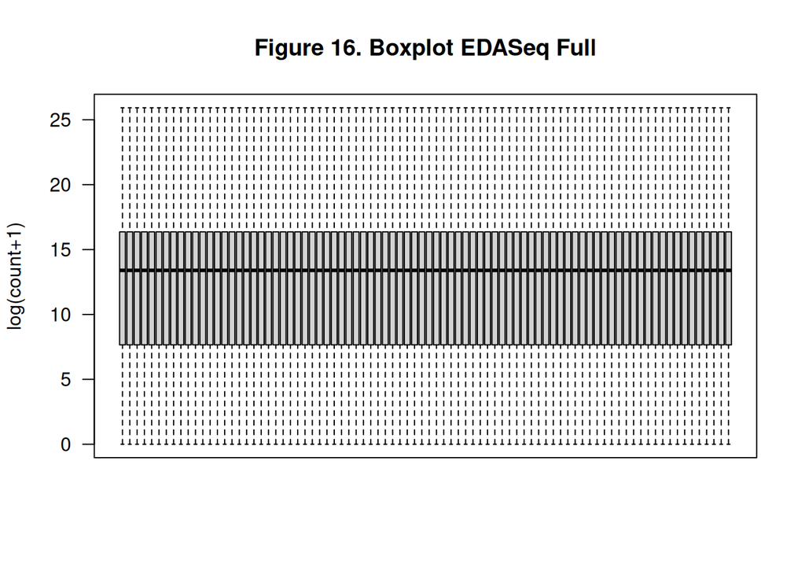

```r
# Boxplot for EDASeq full normalization
boxplot(log2(full + 1),
        outline = FALSE,
        las = 2,
        ylab = "log(count+1)",
        main = "Figure 16. Boxplot EDASeq Full",
        xaxt = "n")
```

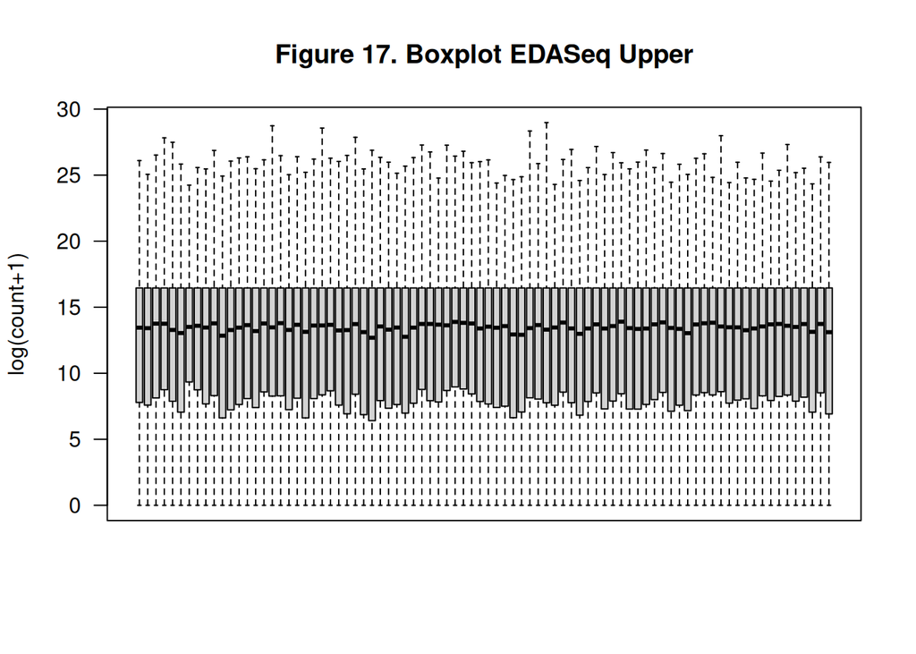

```r
# Boxplot for EDASeq upper normalization
boxplot(log2(uq_edaseq + 1),
        outline = FALSE,
        las = 2,
        ylab = "log(count+1)",
        main = "Figure 17. Boxplot EDASeq Upper",
        xaxt = "n")
```

In conclusion, Figures 14 and 15 show how the samples align across the horizontal axis after normalization. In contrast, Figures 16 and 17 indicate that the full method applied a stronger correction to the data, while the upper method produced a more moderate normalization and appeared to preserve the original sample distributions more effectively.

However, previous studies, including Liu et al. (2021), describe the edgeR package as an efficient approach for RNA-seq normalization, particularly for differential gene expression analysis. Therefore, this analysis additionally evaluated three normalization methods implemented in *edgeR* package: RLE, TMM, and Upper Quartile by using the `calcNormFactors` and `cpm` functions.

```r
# Update `raw_counts` to exclude genes with counts < 10
raw_counts <- assay(breastcancer_sel, "raw_counts")
dim(raw_counts)
```

```
## [1] 26772    84
```

```r
# Compute normalization factors using the RLE normalization method
lbs_rle <- calcNormFactors(raw_counts, method = "RLE")
```

```
## calcNormFactors has been renamed to normLibSizes
```

```r
# Generate an RLE-normalized expression matrix in counts per million (CPM)
rle <- cpm(raw_counts, lib.size = lbs_rle * colSums(raw_counts))


# Compute normalization factors using the TMM normalization method
lbs_tmm <- calcNormFactors(raw_counts, method = "TMM")
```

```
## calcNormFactors has been renamed to normLibSizes
```

```r
# Generate a TMM-normalized expression matrix in counts per million (CPM)
tmm <- cpm(raw_counts, lib.size = lbs_tmm * colSums(raw_counts))


# Compute normalization factors using the Upper Quartile normalization method
lbs_uq <- calcNormFactors(raw_counts, method = "upperquartile")
```

```
## calcNormFactors has been renamed to normLibSizes
```

```r
# Generate an Upper Quartile-normalized expression matrix in counts per million (CPM)
uq <- cpm(raw_counts, lib.size = lbs_uq * colSums(raw_counts))
```

### 2.2.1 Boxplot

Expression matrix visualization after normalization using boxplot.

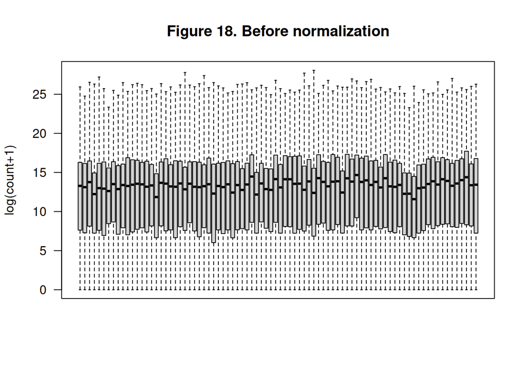

```r
boxplot(log2(raw_counts + 1), outline = FALSE,  las=2,
        ylab = "log(count+1)", main = "Figure 18. Before normalization", xaxt = 'n')
```

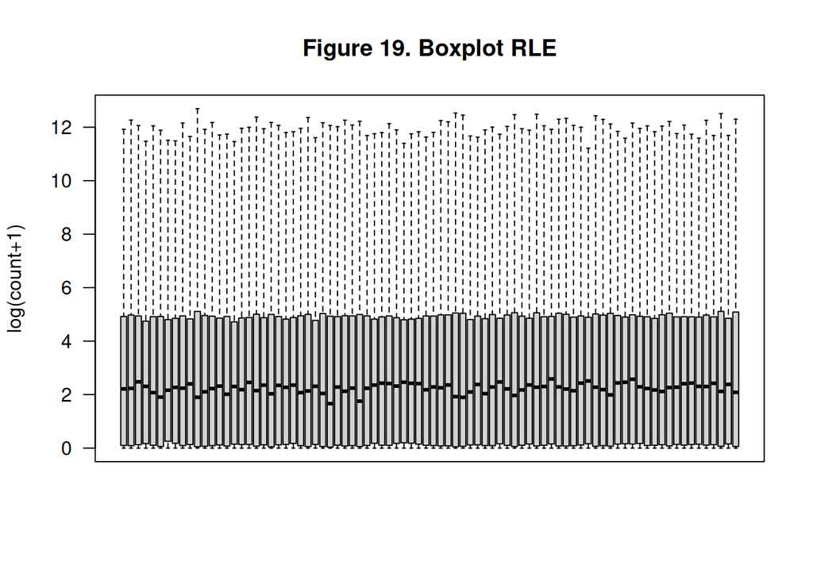

```r
boxplot(log2(rle + 1), outline=FALSE,  las=2,
        ylab = "log(count+1)", main = "Figure 19. Boxplot RLE", xaxt = 'n')
```

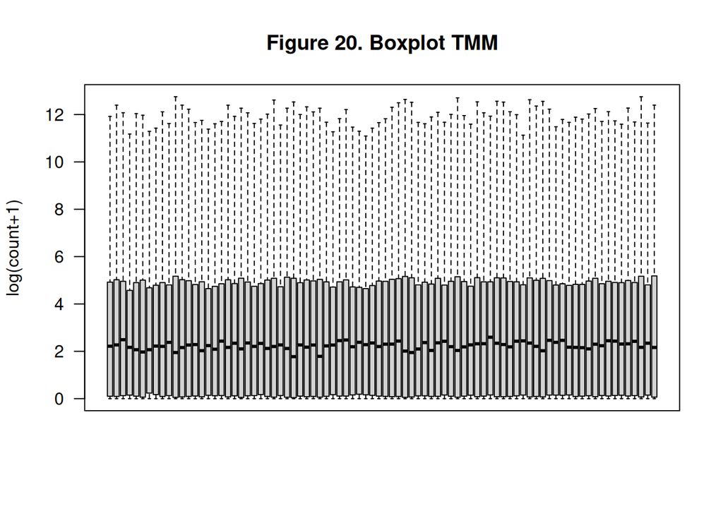

```r
boxplot(log2(tmm + 1), outline=FALSE,  las=2,
        ylab = "log(count+1)", main = "Figure 20. Boxplot TMM", xaxt = 'n')
```

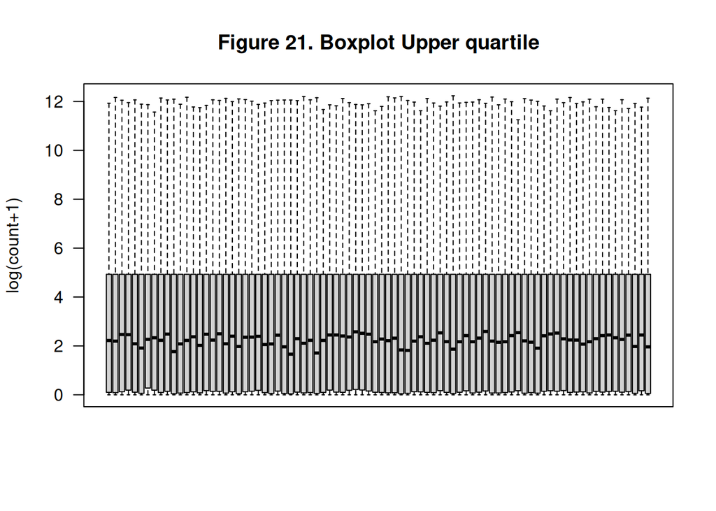

```r
boxplot(log2(uq + 1), outline=FALSE,  las=2,
        ylab = "log(count+1)", main = "Figure 21. Boxplot Upper quartile", xaxt = 'n')
```

### 2.2.2 RLE plot

Expression matrix visualization after normalization using RLE plot.

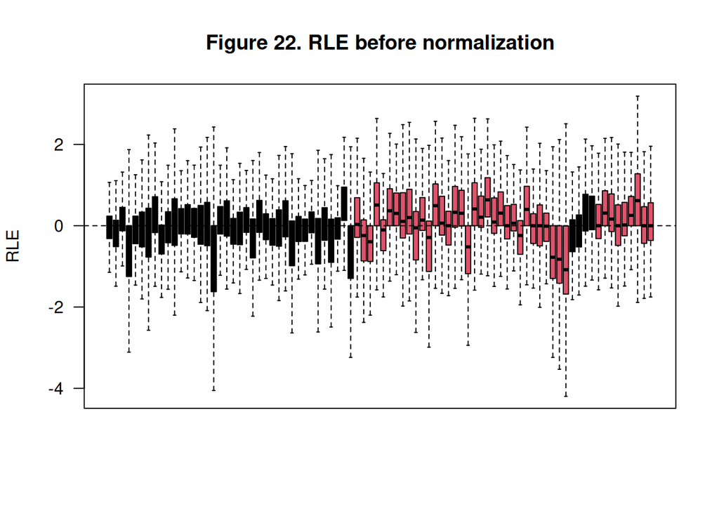

```r
EDASeq::plotRLE(raw_counts, outline = FALSE,  las=2, col=col,
        ylab = "RLE", main = "Figure 22. RLE before normalization", xaxt='n')
```

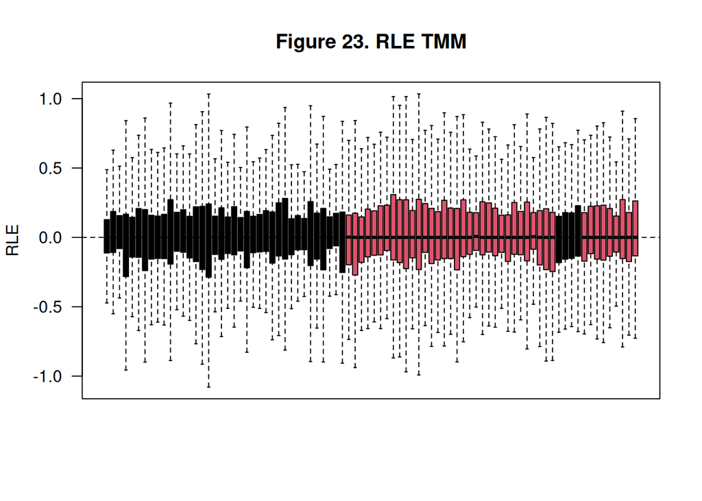

```r
EDASeq::plotRLE(tmm, outline = FALSE,  las=2, col=col,
        ylab = "RLE", main = "Figure 23. RLE TMM", xaxt='n')
```

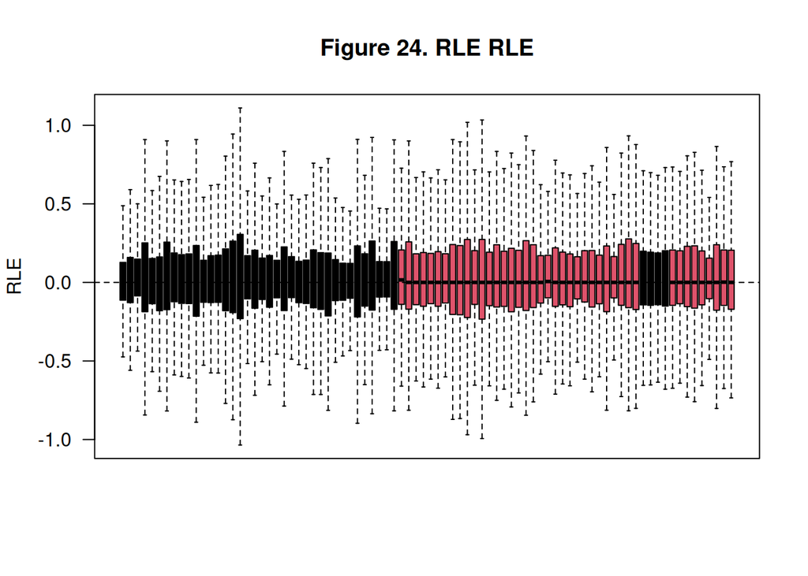

```r
EDASeq::plotRLE(rle, outline = FALSE,  las=2, col=col,
        ylab = "RLE", main = "Figure 24. RLE RLE", xaxt='n')
```

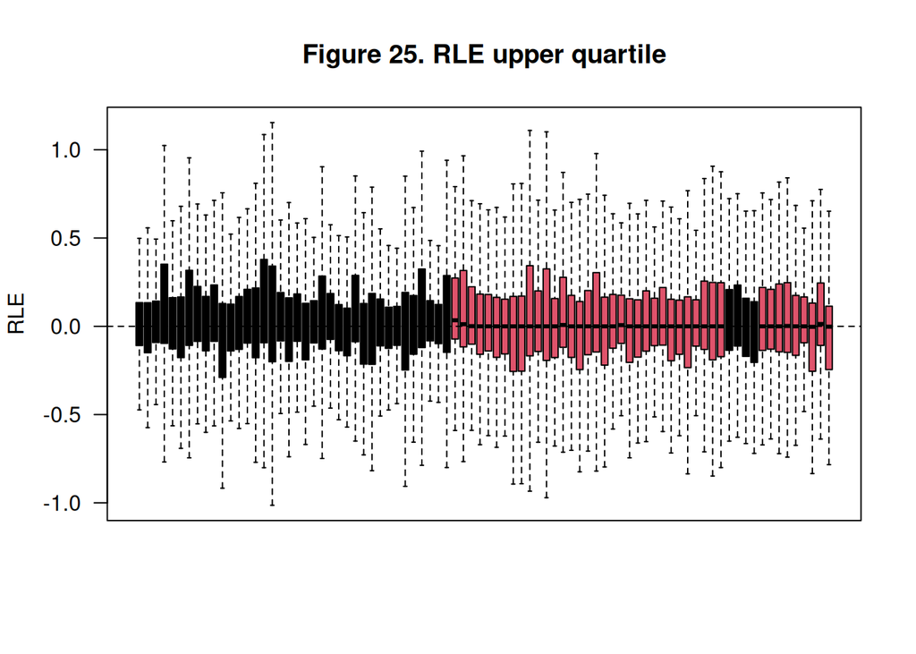

```r
EDASeq::plotRLE(uq, outline = FALSE,  las=2, col=col,
        ylab = "RLE", main = "Figure 25. RLE upper quartile", xaxt='n')
```

As mentioned previously, three normalization approaches were evaluated in this analysis: RLE, TMM, and Upper Quartile. RLE normalizes samples using median expression ratios under the assumption that most genes are not differentially expressed, TMM corrects composition bias by reducing the influence of extremely expressed genes, and Upper Quartile normalization scales samples using the upper portion of the count distribution to reduce the effect of low and extreme counts.

As observed in the literature, the TMM method appears to provide an effective normalization approach because it corrects technical variation without introducing overly strong adjustments to the data. This can be observed in Figure 20 (Boxplot TMM) and Figure 23 (RLE Plot TMM), where the sample distributions appear more aligned and centered after normalization. Based on these results, TMM was selected as the most suitable normalization method for downstream differential gene expression analysis.

## 2.3 Correlation plot

Given the TMM normalization, we visualize the correlation plot, estimating the Pearson correlation index matrix with the `corrplot` function:

```r
# Check dimensions of the TMM-normalized matrix
dim(tmm)
```

```
## [1] 26772    84
```

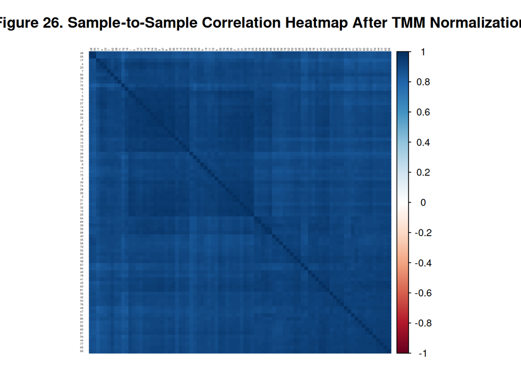

```r
# Save original sample names from tmm because we will have to convert them to numerical values for plotting
sample_names <- colnames(tmm)

# Rename tmm samples numerically for clearer labels on the plot
colnames(tmm) <- as.character(seq_len(ncol(tmm)))

# Compute sample-to-sample correlation matrix
m <- cor(log1p(tmm))

# Plot correlation heatmap with visible sample labels
corrplot(
  m,
  method = "color",
  order = "hclust",
  tl.pos = "lt",
  tl.cex = 0.2,
  tl.col = "black",
  title = "Figure 26. Sample-to-Sample Correlation Heatmap After TMM Normalization",
  mar = c(1, 1, 3, 1)
)
```

```r
# Restore original tmm sample names (i.e., we are done plotting, we do not need numerical values for samples' labels)
colnames(tmm) <- sample_names
```

As shown in Figure 26, all pairs of samples displayed high correlation values, with no evident outlier samples observed within the cohort. The strong correlations between samples suggest that the dataset is technically consistent and biologically coherent, indicating that the RNA-seq libraries were processed similarly and are not strongly affected by technical noise or batch effects.

In RNA-seq datasets, most genes are generally expected to exhibit similar expression patterns across samples, while only a subset of genes show major biological differences. Therefore, the high overall correlation observed after TMM normalization increases confidence that downstream analyses, such as PCA, clustering, and differential gene expression, are mainly driven by biological variation rather than technical artifacts.

### 2.3.1 PCA with TMM normalization method

```r
#Q.C: Number of components contributing to the variance

# Perform PCA on the log1p-transformed TMM-normalized expression matrix
# t() transposes the matrix so samples become rows and genes become columns
breastcancer_pca_tmm <- prcomp(t(log1p(tmm)))

# Generate a summary of the PCA results
tmp_tmm <- summary(breastcancer_pca_tmm)

# Display the proportion of variance explained by the first 35 principal components
tmp_tmm$importance[, 1:35]
```

```
##                             PC1      PC2      PC3      PC4      PC5      PC6
## Standard deviation     36.76638 29.88742 23.16786 16.59489 16.05218 14.12178
## Proportion of Variance  0.18061  0.11935  0.07172  0.03680  0.03443  0.02665
## Cumulative Proportion   0.18061  0.29996  0.37167  0.40847  0.44290  0.46954
##                             PC7      PC8      PC9     PC10     PC11     PC12
## Standard deviation     13.46101 12.41467 12.01406 11.85829 11.43526 11.14871
## Proportion of Variance  0.02421  0.02059  0.01929  0.01879  0.01747  0.01661
## Cumulative Proportion   0.49375  0.51434  0.53363  0.55242  0.56989  0.58650
##                            PC13     PC14     PC15     PC16     PC17     PC18
## Standard deviation     10.56052 10.32633 10.05481 9.633908 9.538587 9.406708
## Proportion of Variance  0.01490  0.01425  0.01351 0.012400 0.012160 0.011820
## Cumulative Proportion   0.60140  0.61564  0.62915 0.641550 0.653710 0.665530
##                            PC19     PC20     PC21     PC22    PC23     PC24
## Standard deviation     8.968692 8.836875 8.702339 8.656084 8.45481 8.321767
## Proportion of Variance 0.010750 0.010430 0.010120 0.010010 0.00955 0.009250
## Cumulative Proportion  0.676280 0.686710 0.696830 0.706840 0.71639 0.725650
##                            PC25     PC26     PC27    PC28     PC29     PC30
## Standard deviation     8.259512 8.002986 7.958139 7.83741 7.697767 7.600905
## Proportion of Variance 0.009110 0.008560 0.008460 0.00821 0.007920 0.007720
## Cumulative Proportion  0.734760 0.743320 0.751780 0.75999 0.767900 0.775620
##                            PC31     PC32     PC33     PC34     PC35
## Standard deviation     7.547976 7.455848 7.344818 7.219214 7.200382
## Proportion of Variance 0.007610 0.007430 0.007210 0.006960 0.006930
## Cumulative Proportion  0.783240 0.790660 0.797870 0.804830 0.811760
```

The first principal components explained the largest proportion of variance in the dataset, with PC1 and PC2 together accounting for approximately 30% of the total variability in gene expression.

A PCA plot was subsequently generated using the TMM-normalized data, where ER and TNBC samples were differentiated according to subtype using distinct colors.

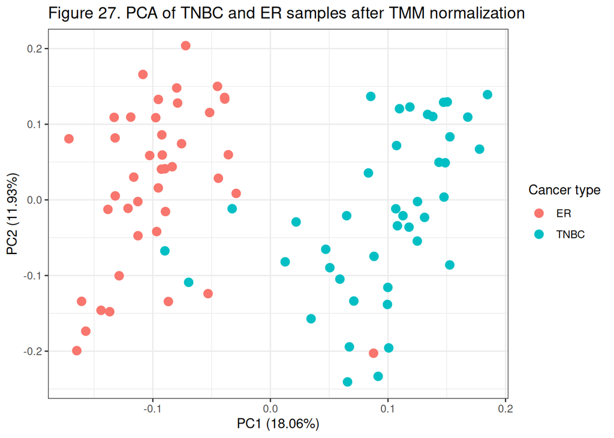

```r
# make sure group is a factor in the correct order
colData(breastcancer_sel)$group <- factor(colData(breastcancer_sel)$group,
                                      levels = c("ER", "TNBC"))

# PCA plot colored by cancer type
autoplot(
  breastcancer_pca_tmm,
  data = as.data.frame(colData(breastcancer_sel)),
  colour = "group",
  size = 3
) +
  labs(title = "Figure 27. PCA of TNBC and ER samples after TMM normalization",
       colour = "Cancer type") +
  theme_bw()
```

Comparison between Figure 5 (PCA before normalization) and Figure 27 (PCA after TMM normalization) shows that normalization substantially changed the variance structure of the dataset. After TMM normalization, the proportion of variance explained by PC1 increased from 9.31% to 18.06%, while the variance explained by PC2 increased from 6.51% to 11.93%.

These changes suggest that normalization successfully reduced technical variation and improved the representation of biologically meaningful differences within the dataset. As a result, the principal components captured a larger proportion of the true gene expression variability between ER and TNBC samples after normalization.

# 3 Inference with edgeR

Before proceeding with differential gene expression analysis using edgeR, the biological groups corresponding to the two breast cancer subtypes of interest, Triple Negative Breast Cancer (TNBC) and Estrogen Receptor Positive (ER+), were reintroduced from the previously processed breastcancer dataset. The dataset was then inspected to confirm the presence of the two groups, with 42 samples retained for both the ER and TNBC subtypes.

```r
table(breastcancer_sel$group)
```

```
##
##   ER TNBC
##   42   42
```

# 4 Exploring the mean-variance relationship

First we explored the mean-variance relationship on the breastcancer dataset. In RNA-seq data the variance is typically larger than the mean, a phenomenon called overdispersion. The distribution for over-dispersed counts is the Negative Binomial distribution (NB), where $Var(Y)=μ+ϕμ^2$ (quadratic relationship between the mean and the variance).

The estimated dispersion was computed with *edgeR* package.

```r
design <- model.matrix(~ group, data = colData(breastcancer_sel))
head(design)
```

```
##            (Intercept) groupTNBC
## SRR1313092           1         0
## SRR1313090           1         0
## SRR1313091           1         0
## SRR1313093           1         0
## SRR1313094           1         0
## SRR1313095           1         0
```

The dge object created below is a special object from the `edgeR` package. It takes the breastcancer_sel raw counts and organizes them into a structure that `edgeR` can use. Initially, it contains: * counts matrix (rows = genes, columns = samples) * library sizes (total reads per sample) * After later steps, it will also contain: normalization factors, dispersion estimates, model results.

`edgeR` package requires the dge object to later run: * calcNormFactors() * estimateDisp() * glmFit()

```r
# Create a DGEList object
dge <- DGEList(assay(breastcancer_sel, "raw_counts"))
```

In addition, scaling factors were computed below using the `calcNormFactors()` function to convert the observed library sizes into normalized values.

The effective library sizes used in downstream analyses are calculated as lib.size * norm.factors, where lib.size contains the original library sizes and norm.factors is the vector of scaling factors computed by this function. The effective library sizes are incorporated into the model that estimates dispersion. The function `plotMeanVar(`) in `edgeR` is used to visualize the relationship between gene expression levels (mean) and variability (variance).

```r
dge <- calcNormFactors(dge, method="TMM") #using normalized counts by TMM scaling factors
```

```
## calcNormFactors has been renamed to normLibSizes
```

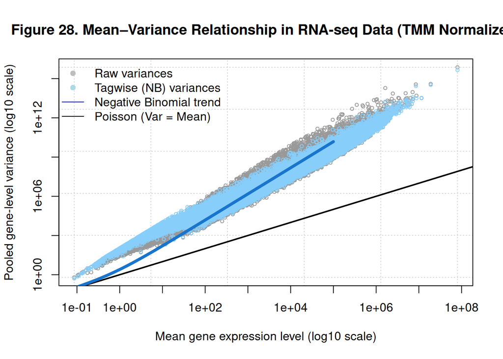

```r
dge <- estimateDisp(dge, design)

plotMeanVar(dge,
            show.raw.vars = TRUE,
            show.ave.raw.vars = FALSE,
            NBline = TRUE,
            show.tagwise.vars = TRUE,
            main = "Figure 28. Mean–Variance Relationship in RNA-seq Data (TMM Normalized)")
# show.raw.vars = TRUE -> raw variances: directly from counts before modeling
# show.tagwise.vars = TRUE -> modeled variances: after dispersion estimation (i.e., Negative Binomial)

legend("topleft",
       legend = c("Raw variances",
                  "Tagwise (NB) variances",
                  "Negative Binomial trend",
                  "Poisson (Var = Mean)"),
       col = c("grey", "lightblue", "blue", "black"),
       pch = c(16, 16, NA, NA),
       lty = c(NA, NA, 1, 1),
       bty = "n")
```

As shown in figure 28, each point represents a gene, showing how its average expression relates to its variability. Most genes lie above the black Poisson line, meaning the data are more variable than expected and show overdispersion. The blue line (Negative Binomial) follows the data much better, indicating it is a more appropriate model for RNA-seq counts. This confirms that using a Negative Binomial model with dispersion estimates is necessary for accurate differential expression analysis.

# 5 Identification of differentially expressed genes

We fit a Negative Binomial generalized linear model (GLM) to the count data for each gene using glmFit(). After normalization, the counts are effectively adjusted through scaling factors. To account for these normalized library sizes, an offset is included in the GLM: $log(E[Y|X]) = X\beta + O$, where $log(E[Y|X])$ is the link function for negative binomial distribution and $X\beta$ represents the linear predictor, and $O$ is the offset that incorporates the effective library sizes.

```r
# Negative Binomial generalized linear model (GLM) for each gene using the experimental design matrix (ER vs TNBC)
fit <- glmFit(dge, design)

# Display the offset values for the first 20 samples after normalization
fit$offset[,1:20]
```

```
##          [,1]     [,2]     [,3]     [,4]     [,5]     [,6]     [,7]     [,8]
## [1,] 21.73113 21.56585 21.82832 21.04293 21.66388 21.70482 21.40284 21.88189
##          [,9]    [,10]    [,11]    [,12]    [,13]    [,14]    [,15]    [,16]
## [1,] 21.44989 21.66282 21.96277 21.88299 21.87268 21.80526 21.82496 21.74465
##         [,17]    [,18]    [,19]    [,20]
## [1,] 20.85095 21.81398 21.97945 21.56956
## attr(,"class")
## [1] "CompressedMatrix"
## attr(,"Dims")
## [1] 26772    20
## attr(,"repeat.row")
## [1] TRUE
## attr(,"repeat.col")
## [1] FALSE
```

Once the model parameters have been estimated, we can perform the differential expression test for each gene, using the glmLRT() function. By specifying coef = 2 (er =0 vs tnbc = 1), the null hypothesis is $H0:\beta_2=0$, which tests whether the effect of this condition is significantly different from zero. Bellow are ten differentially expressed genes sorted by log fold-change (logFC), using the `topTags()` function:

```r
# Perform a likelihood ratio test (LRT) on the TNBC coefficient for each gene
res <- glmLRT(fit, coef=2)

# Display the top differentially expressed genes sorted by log fold-change (logFC)
topTags(res, sort.by="logFC")
```

```
## Coefficient:  groupTNBC
##                        logFC     logCPM        LR       PValue          FDR
## ENSG00000171209.3  10.974735  6.9822446 105.13688 1.139834e-24 3.632813e-22
## ENSG00000057149.15  9.604123  1.8685066  37.02860 1.164090e-09 1.723729e-08
## ENSG00000170893.3  -9.117493  5.7794559 100.77972 1.028036e-23 2.646402e-21
## ENSG00000164326.4  -8.726604  3.9305781  25.03791 5.621415e-07 4.568917e-06
## ENSG00000169488.5  -8.466274 -6.9897700  15.00038 1.074896e-04 4.878302e-04
## ENSG00000153002.11 -8.456617  9.1979915  82.03986 1.333696e-19 1.579898e-17
## ENSG00000169469.8   8.439229  2.0774630  27.73050 1.394468e-07 1.312683e-06
## ENSG00000264788.1  -8.327585 -7.0800000  10.63792 1.107925e-03 3.802941e-03
## ENSG00000155622.6   8.129550 -0.8504876  18.42994 1.762664e-05 9.760091e-05
## ENSG00000187689.9   7.969514  2.0907345  40.96792 1.547483e-10 2.833736e-09
```

For each gene:

- *logFC* measures how much the gene changes between the two condition.
- Positive → gene is higher in TNBC
- Negative → gene is higher in ER
- *logCPM* is the average expression.
- How much the gene is expressed overall
- Higher values = more reliable signal
- *LR* is the test statistic.
- Strength of evidence against null
- Higher values = stronger difference
- *P-value* is the p-value.
- Probability the difference is by chance
- Very small values = strong evidence
- *FDR* is adjusted p-value (multiple testing).
- Corrected for multiple testing
- < 0.05 : significant gene

For example, gene ENSG00000171209.3 shows a very high positive logFC (10.97), indicating substantially higher expression in TNBC compared to ER samples. In addition, the extremely small P-value and FDR provide strong evidence that this gene is significantly differentially expressed between the two breast cancer subtypes.

In addition, an object named `tab` was created to store and visualize the differentially expressed genes identified from the edgeR analysis. The topTags() function was used to extract all genes ranked according to statistical significance, including genes with an FDR threshold below 0.05.

```r
# Extract all differentially expressed genes identified from the edgeR analysis
tab <- topTags(res, n=Inf)

# Store the differential expression results as a table
tab <- tab$table

# Display the first rows of the differential expression table
head(tab)
```

```
##                        logFC   logCPM       LR       PValue          FDR
## ENSG00000143412.9  -3.049743 4.938860 233.1116 1.249634e-52 3.345520e-48
## ENSG00000176597.11  3.077512 3.533030 196.5106 1.205982e-44 1.614327e-40
## ENSG00000134830.5  -3.279182 3.892917 185.3401 3.307941e-42 2.952006e-38
## ENSG00000248360.7  -4.780496 4.412170 170.5959 5.483017e-39 3.669783e-35
## ENSG00000109436.7  -3.274284 7.046147 168.2959 1.743267e-38 9.334148e-35
## ENSG00000170469.10 -2.599694 2.253211 166.1466 5.138461e-38 2.292781e-34
```

```r
#Check dimensions of tab
dim(tab)
```

```
## [1] 26772     5
```

Moreover, a new object named de was created to retain only significantly differentially expressed genes identified from the edgeR analysis using an FDR threshold below 0.05.

```r
# Extract differentially expressed genes with an FDR threshold below 0.05.
de <- tab[tab$FDR <0.05,]

#Check dimensions of de
dim(de)
```

```
## [1] 11517     5
```

While the dge object retained all 26772 genes together with normalization and dispersion estimates, the de object filtered this set to 11517 significantly differentially expressed genes based on the selected statistical threshold.

# 6 DEGs exploration

## 6.1 MD plot

First, the MD plot was visualized, comparing the log-fold changes (*logFC) with the average log counts per million (logCPM*). Black points correspond to non-significant genes, while red and blue points indicate up- and down-regulated genes, respectively.

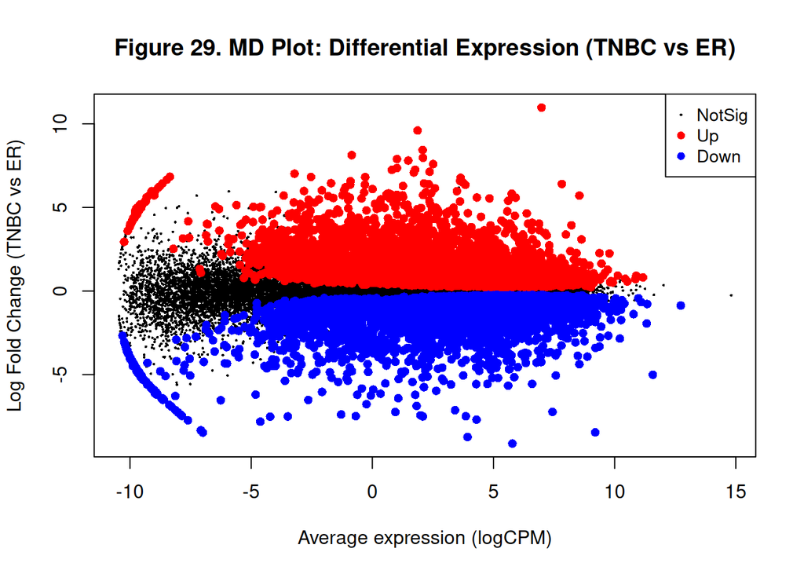

```r
plotMD(res,
       main = "Figure 29. MD Plot: Differential Expression (TNBC vs ER)",
       xlab = "Average expression (logCPM)",
       ylab = "Log Fold Change (TNBC vs ER)")
```

Figure 29 shows how gene expression differs between TNBC and ER samples. Red points are genes expressed higher in TNBC, blue points are higher in ER, and black points are not significantly different. A large number of significant genes show positive or negative logFC values, indicating strong differential expression. Hence, there is a clear biological separation between the two cancer types.

## 6.2 Volcano plot

A volcano plot is a graphical representation of *logFC* vs *-log10(PValue)* with the possibility to highlight some genes of interest.

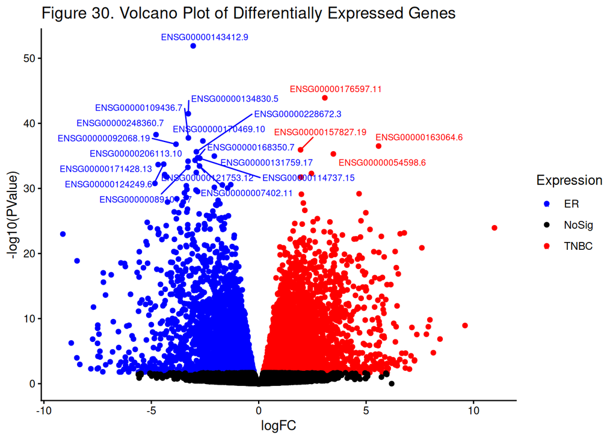

```r
# Store the names of significantly differentially expressed genes
names <- row.names(de)

# Create a new column to classify genes according to expression direction
tab$sign <- NA

# Label genes with negative logFC as downregulated and upregulated
tab$sign[tab$logFC < 0] <- "ER"
tab$sign[tab$logFC > 0] <- "TNBC"

# Label non-significant genes based on FDR threshold
tab$sign[tab$FDR >= 0.05] <- "NoSig"

# Store gene names as a separate column for labeling in the plot
tab$gene <- rownames(tab)

ggplot(tab, aes(x = logFC,y = -log10(PValue),color = sign)) + geom_point() +  theme_classic() +scale_color_manual(values = c("ER" = "blue", "TNBC" = "red", "NoSig" = "black")) + geom_text_repel(data = tab[1:20, ],aes(label = gene),size = 2.5,max.overlaps = 20) +labs(title = "Figure 30. Volcano Plot of Differentially Expressed Genes", x = "logFC", y = "-log10(PValue)", color = "Expression")
```

Figure 30 shows differential expression between TNBC and ER. Genes far on the left or right (x-axis) have large differences in expression (high absolute logFC), while genes higher on the y-axis are more statistically significant (lower p-values). Red genes are higher in TNBC, blue genes are higher in ER, and black genes are not significant.